# Project 2

Yilin Xie July 3, 2020

## Introduction

The perpose of this project is going to analyze an online news popularity data set [here](https://archive.ics.uci.edu/ml/datasets/Online+News+Popularity) and predict **shares** by backward linear regression and random forest. Firstly I read it into R session and determine which variables that I would deal with.

```r
#Load the data
news <- read.csv("/Users/yilinxie/Desktop/ST558/Project/Project2/OnlineNewsPopularity.csv")
head(news)
```

```
##                                                              url timedelta n_tokens_title n_tokens_content
## 1   http://mashable.com/2013/01/07/amazon-instant-video-browser/       731             12              219
## 2    http://mashable.com/2013/01/07/ap-samsung-sponsored-tweets/       731              9              255
## 3 http://mashable.com/2013/01/07/apple-40-billion-app-downloads/       731              9              211
## 4       http://mashable.com/2013/01/07/astronaut-notre-dame-bcs/       731              9              531
## 5               http://mashable.com/2013/01/07/att-u-verse-apps/       731             13             1072
## 6               http://mashable.com/2013/01/07/beewi-smart-toys/       731             10              370
##   n_unique_tokens n_non_stop_words n_non_stop_unique_tokens num_hrefs num_self_hrefs num_imgs num_videos
## 1       0.6635945                1                0.8153846         4              2        1          0
## 2       0.6047431                1                0.7919463         3              1        1          0
## 3       0.5751295                1                0.6638655         3              1        1          0
## 4       0.5037879                1                0.6656347         9              0        1          0
## 5       0.4156456                1                0.5408895        19             19       20          0
## 6       0.5598886                1                0.6981982         2              2        0          0
##   average_token_length num_keywords data_channel_is_lifestyle data_channel_is_entertainment data_channel_is_bus
```

[output cut: 62 more lines]

```r
#detect NA value
sum(is.na(news$shares) )
```

```
## [1] 0
```

As shown above, it is a huge data set with 39644 rows and 61 colomns. It contains factor variables, numeric variables and dummy variables. The task is to predict the 61st variable **shares**. Then I’m going to preprocess the data to get it in the form I need.

### Data preprocessing

```r
library(tidyverse)
#Remove the useless colomns
news1 <- select(news, -url, -timedelta,
                -weekday_is_monday, -weekday_is_tuesday,
                -weekday_is_wednesday, -weekday_is_thursday,
                -weekday_is_friday, -weekday_is_saturday, -weekday_is_sunday,
                -is_weekend, params$weekday)
r = nrow(news1)
c = ncol(news1)
r
```

```
## [1] 39644
```

```r
c
```

```
## [1] 52
```

### Data split

```r
#Set seed to make work reproducible
set.seed(123)
#randomly sample from the data
sub <- sample(1:r, 0.7*r)
#store training dataset (70% of the data) and test dataset (30% of the data)
train <- news1[sub,]
test <- news1[-sub,]
```

### Summarizations

We can look at the distribution of **shares** through the histogram and see some statistics of the total variables in a summary table.

```r
#number of rows of training dataset
nrow(train)
```

```
## [1] 27750
```

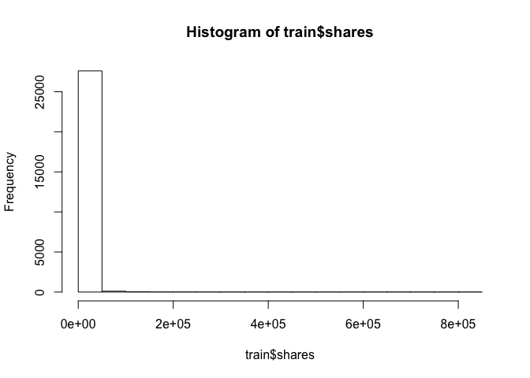

```r
#draw histograms
hist(train$shares)
```

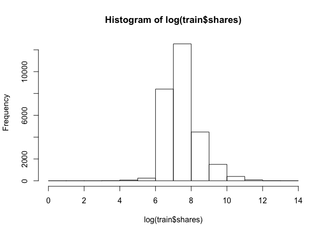

```r
hist(log(train$shares))
```

```r
#summary the training dataset
t(summary(train))
```

```
##
## n_tokens_title                Min.   : 3.00      1st Qu.: 9.00      Median :10.00      Mean   :10.41
## n_tokens_content              Min.   :   0.0     1st Qu.: 246.0     Median : 409.0     Mean   : 546.6
## n_unique_tokens               Min.   :  0.0000   1st Qu.:  0.4707   Median :  0.5391   Mean   :  0.5554
## n_non_stop_words              Min.   :   0.000   1st Qu.:   1.000   Median :   1.000   Mean   :   1.007
## n_non_stop_unique_tokens      Min.   :  0.0000   1st Qu.:  0.6253   Median :  0.6905   Mean   :  0.6958
##   num_hrefs                   Min.   :  0.00     1st Qu.:  4.00     Median :  8.00     Mean   : 10.96
## num_self_hrefs                Min.   :  0.000    1st Qu.:  1.000    Median :  3.000    Mean   :  3.314
##    num_imgs                   Min.   :  0.000    1st Qu.:  1.000    Median :  1.000    Mean   :  4.533
##   num_videos                  Min.   : 0.000     1st Qu.: 0.000     Median : 0.000     Mean   : 1.248
## average_token_length          Min.   :0.000      1st Qu.:4.477      Median :4.664      Mean   :4.545
##  num_keywords                 Min.   : 1.000     1st Qu.: 6.000     Median : 7.000     Mean   : 7.219
## data_channel_is_lifestyle     Min.   :0.00000    1st Qu.:0.00000    Median :0.00000    Mean   :0.05359
## data_channel_is_entertainment Min.   :0.0000     1st Qu.:0.0000     Median :0.0000     Mean   :0.1767
## data_channel_is_bus           Min.   :0.0000     1st Qu.:0.0000     Median :0.0000     Mean   :0.1595
## data_channel_is_socmed        Min.   :0.00000    1st Qu.:0.00000    Median :0.00000    Mean   :0.05888
## data_channel_is_tech          Min.   :0.0000     1st Qu.:0.0000     Median :0.0000     Mean   :0.1843
## data_channel_is_world         Min.   :0.0000     1st Qu.:0.0000     Median :0.0000     Mean   :0.2134
##   kw_min_min                  Min.   : -1.00     1st Qu.: -1.00     Median : -1.00     Mean   : 26.16
##   kw_max_min                  Min.   :     0     1st Qu.:   444     Median :   659     Mean   :  1154
##   kw_avg_min                  Min.   :   -1.0    1st Qu.:  141.6    Median :  235.2    Mean   :  312.5
##   kw_min_max                  Min.   :     0     1st Qu.:     0     Median :  1400     Mean   : 13874
##   kw_max_max                  Min.   :     0     1st Qu.:843300     Median :843300     Mean   :751872
##   kw_avg_max                  Min.   :     0     1st Qu.:173184     Median :244999     Mean   :259451
##   kw_min_avg                  Min.   :  -1       1st Qu.:   0       Median :1028       Mean   :1119
##   kw_max_avg                  Min.   :     0     1st Qu.:  3564     Median :  4358     Mean   :  5653
##   kw_avg_avg                  Min.   :    0      1st Qu.: 2383      Median : 2876      Mean   : 3134
## self_reference_min_shares     Min.   :     0.0   1st Qu.:   640.2   Median :  1200.0   Mean   :  3972.7
## self_reference_max_shares     Min.   :     0     1st Qu.:  1000     Median :  2800     Mean   : 10287
## self_reference_avg_sharess    Min.   :     0.0   1st Qu.:   975.4   Median :  2200.0   Mean   :  6350.6
##     LDA_00                    Min.   :0.00000    1st Qu.:0.02505    Median :0.03339    Mean   :0.18615
##     LDA_01                    Min.   :0.00000    1st Qu.:0.02501    Median :0.03334    Mean   :0.14033
##     LDA_02                    Min.   :0.00000    1st Qu.:0.02857    Median :0.04000    Mean   :0.21606
##     LDA_03                    Min.   :0.00000    1st Qu.:0.02857    Median :0.04000    Mean   :0.22337
##     LDA_04                    Min.   :0.00000    1st Qu.:0.02857    Median :0.04072    Mean   :0.23405
## global_subjectivity           Min.   :0.0000     1st Qu.:0.3959     Median :0.4533     Mean   :0.4430
## global_sentiment_polarity     Min.   :-0.39375   1st Qu.: 0.05761   Median : 0.11851   Mean   : 0.11894
## global_rate_positive_words    Min.   :0.00000    1st Qu.:0.02830    Median :0.03904    Mean   :0.03957
## global_rate_negative_words    Min.   :0.000000   1st Qu.:0.009615   Median :0.015385   Mean   :0.016668
## rate_positive_words           Min.   :0.0000     1st Qu.:0.6000     Median :0.7097     Mean   :0.6806
```

[output cut: 51 more lines]

```
## global_rate_negative_words    3rd Qu.:0.021779   Max.   :0.184932
## rate_positive_words           3rd Qu.:0.8000     Max.   :1.0000
## rate_negative_words           3rd Qu.:0.3846     Max.   :1.0000
## avg_positive_polarity         3rd Qu.:0.4117     Max.   :1.0000
## min_positive_polarity         3rd Qu.:0.10000    Max.   :1.00000
## max_positive_polarity         3rd Qu.:1.0000     Max.   :1.0000
## avg_negative_polarity         3rd Qu.:-0.1863    Max.   : 0.0000
## min_negative_polarity         3rd Qu.:-0.3000    Max.   : 0.0000
## max_negative_polarity         3rd Qu.:-0.0500    Max.   : 0.0000
## title_subjectivity            3rd Qu.:0.5000     Max.   :1.0000
## title_sentiment_polarity      3rd Qu.: 0.15000   Max.   : 1.00000
## abs_title_subjectivity        3rd Qu.:0.5000     Max.   :0.5000
## abs_title_sentiment_polarity  3rd Qu.:0.250000   Max.   :1.000000
##     shares                    3rd Qu.:  2800     Max.   :843300
## weekday_is_tuesday            3rd Qu.:0.0000     Max.   :1.0000
```

## Ensemble model fit

A random forest is a forest constructed in a random way, and the forest is composed of many unrelated decision trees. Therefore, in theory, the performance of random forest is generally better than that of a single decision tree, because the results of random forest are determined by voting on the results of multiple decision trees. But here, I’m using a random forest for regression.

### On train set

```r
#load package
library(randomForest)
#Get random forest model fit on training dataset
rf <- randomForest(shares ~ ., data = train, importance=TRUE)
rf
```

```
##
## Call:
##  randomForest(formula = shares ~ ., data = train, importance = TRUE)
##                Type of random forest: regression
##                      Number of trees: 500
## No. of variables tried at each split: 17
##
##           Mean of squared residuals: 117342382
##                     % Var explained: -0.5
```

```r
#variable importance measures
importance(rf)
```

```
##                                  %IncMSE IncNodePurity
## n_tokens_title                -0.2479843   37915947192
## n_tokens_content               4.7382524   37412807470
## n_unique_tokens                7.2853766   42311741103
## n_non_stop_words               3.2409864   37923841870
## n_non_stop_unique_tokens       6.8656113   54825306981
## num_hrefs                      4.1135361   63510666153
## num_self_hrefs                 3.1749672   49216149095
## num_imgs                       2.2765801   46285166885
## num_videos                     6.3316179   40268634032
## average_token_length           3.4044994   55866640685
## num_keywords                   3.0380575   15979075603
## data_channel_is_lifestyle      2.2192243    4352591450
## data_channel_is_entertainment  5.4164212    4173547695
## data_channel_is_bus            3.8422105   22816381111
## data_channel_is_socmed         3.4398771    2465566135
## data_channel_is_tech           9.5405902    1715443259
## data_channel_is_world          7.8972386    3146823707
## kw_min_min                     2.0762109   21661935884
## kw_max_min                     3.2161132   90857925659
## kw_avg_min                     4.4990703  102745647393
## kw_min_max                     4.9047293   42913726472
## kw_max_max                     3.9140745   57059562284
## kw_avg_max                     4.2341100  132011003269
## kw_min_avg                     4.1839315   57323345236
## kw_max_avg                     4.1738388  184188161939
## kw_avg_avg                     3.0584241  194767838772
## self_reference_min_shares      8.0182723   60717391012
## self_reference_max_shares      5.2207680   77142574223
## self_reference_avg_sharess     5.1010296  140853297974
## LDA_00                         3.6902074   98898908923
## LDA_01                         9.0034638   53282877459
## LDA_02                         5.9541564   73239188753
## LDA_03                         4.2521771  106644881997
## LDA_04                         5.7082479   81492485944
## global_subjectivity            5.2011657   87826050350
## global_sentiment_polarity      6.2781678   57332142185
## global_rate_positive_words     1.5165444   59317955983
## global_rate_negative_words     4.8444526   40523750976
## rate_positive_words            2.3404264   42979223315
## rate_negative_words            2.2081101   41557330065
## avg_positive_polarity          3.8096780   50721613627
## min_positive_polarity          3.5490261   19991548357
## max_positive_polarity          5.2858800   11505628403
## avg_negative_polarity          3.7958339   61755742167
## min_negative_polarity          2.7422260   28673661421
## max_negative_polarity          2.6205432   28459604216
## title_subjectivity             3.7356961   62437468305
## title_sentiment_polarity       3.8359030   64384531938
## abs_title_subjectivity         1.8700338   15990955789
## abs_title_sentiment_polarity   3.1983783   35320883557
## weekday_is_tuesday             0.2165802    4695116749
```

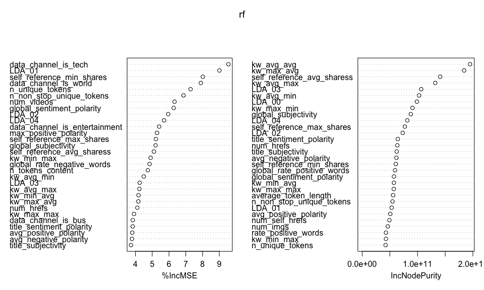

```r
#draw dotplot of variable importance as measured by Random Forest
varImpPlot(rf)
```

Calculate the predicted mean square error on the train set:

```r
train.pred <- predict(rf, train)
mean((train.pred - train$shares)^2)
```

```
## [1] 25796526
```

### On test set

```r
rf.test <- predict(rf, newdata = test)
mean((test$shares-rf.test)^2)
```

```
## [1] 177044761
```

## Linear regression fit

I choose stepwise regression to fit this model, more specificly, the backward way. This data set contains too many variables. And since I’m not an expert on journalism, I can’t tell which factors should have a real effect on the predicted variables. If I manually removed the variables by their significance in the model and compared the differences between the models, this would be a lot of work. So I want to use a backward regression model based on the AIC criteria to automatically determine which variables should be included or removed from the model.

### On train set

```r
#fit model
lm.step <- step(lm(shares ~ .,data = train))
```

```
## Start:  AIC=514897.2
## shares ~ n_tokens_title + n_tokens_content + n_unique_tokens +
##     n_non_stop_words + n_non_stop_unique_tokens + num_hrefs +
##     num_self_hrefs + num_imgs + num_videos + average_token_length +
##     num_keywords + data_channel_is_lifestyle + data_channel_is_entertainment +
##     data_channel_is_bus + data_channel_is_socmed + data_channel_is_tech +
##     data_channel_is_world + kw_min_min + kw_max_min + kw_avg_min +
##     kw_min_max + kw_max_max + kw_avg_max + kw_min_avg + kw_max_avg +
##     kw_avg_avg + self_reference_min_shares + self_reference_max_shares +
##     self_reference_avg_sharess + LDA_00 + LDA_01 + LDA_02 + LDA_03 +
##     LDA_04 + global_subjectivity + global_sentiment_polarity +
##     global_rate_positive_words + global_rate_negative_words +
##     rate_positive_words + rate_negative_words + avg_positive_polarity +
##     min_positive_polarity + max_positive_polarity + avg_negative_polarity +
##     min_negative_polarity + max_negative_polarity + title_subjectivity +
##     title_sentiment_polarity + abs_title_subjectivity + abs_title_sentiment_polarity +
##     weekday_is_tuesday
##
##                                 Df  Sum of Sq        RSS    AIC
## - global_sentiment_polarity      1 2.5548e+05 3.1616e+12 514895
## - title_subjectivity             1 3.9376e+05 3.1616e+12 514895
## - n_unique_tokens                1 1.5625e+06 3.1616e+12 514895
## - global_rate_negative_words     1 2.3674e+06 3.1616e+12 514895
## - LDA_00                         1 4.7538e+06 3.1616e+12 514895
## - LDA_04                         1 4.7586e+06 3.1616e+12 514895
## - LDA_03                         1 4.7606e+06 3.1616e+12 514895
## - LDA_02                         1 4.7650e+06 3.1616e+12 514895
## - LDA_01                         1 4.7658e+06 3.1616e+12 514895
## - avg_negative_polarity          1 6.5056e+06 3.1616e+12 514895
## - num_keywords                   1 6.7844e+06 3.1616e+12 514895
## - rate_positive_words            1 7.6506e+06 3.1616e+12 514895
## - max_positive_polarity          1 8.1383e+06 3.1616e+12 514895
## - rate_negative_words            1 8.4783e+06 3.1616e+12 514895
## - n_non_stop_words               1 1.1727e+07 3.1616e+12 514895
## - n_tokens_content               1 1.3867e+07 3.1616e+12 514895
## - avg_positive_polarity          1 2.2671e+07 3.1616e+12 514895
## - min_negative_polarity          1 2.4353e+07 3.1616e+12 514895
## - title_sentiment_polarity       1 3.7266e+07 3.1616e+12 514895
## - self_reference_avg_sharess     1 4.5446e+07 3.1616e+12 514896
## - max_negative_polarity          1 4.7051e+07 3.1616e+12 514896
```

[output cut: 1372 more lines]

```
## - num_self_hrefs                 1 7.8677e+08 3.1638e+12 514864
## - data_channel_is_world          1 8.1905e+08 3.1638e+12 514865
## - n_tokens_title                 1 8.9791e+08 3.1639e+12 514865
## - abs_title_subjectivity         1 9.2978e+08 3.1639e+12 514866
## - data_channel_is_socmed         1 9.7339e+08 3.1640e+12 514866
## - abs_title_sentiment_polarity   1 1.0224e+09 3.1640e+12 514867
## - global_subjectivity            1 1.3519e+09 3.1644e+12 514869
## - data_channel_is_lifestyle      1 2.0107e+09 3.1650e+12 514875
## - kw_min_avg                     1 2.1497e+09 3.1652e+12 514876
## - data_channel_is_tech           1 2.1546e+09 3.1652e+12 514876
## - data_channel_is_bus            1 2.4403e+09 3.1654e+12 514879
## - data_channel_is_entertainment  1 3.3868e+09 3.1664e+12 514887
## - num_hrefs                      1 3.9391e+09 3.1669e+12 514892
## - kw_max_avg                     1 5.6542e+09 3.1687e+12 514907
## - kw_avg_avg                     1 1.1836e+10 3.1748e+12 514961
```

```r
#summary the model
summary(lm.step)
```

```
##
## Call:
## lm(formula = shares ~ n_tokens_title + num_hrefs + num_self_hrefs +
##     average_token_length + data_channel_is_lifestyle + data_channel_is_entertainment +
##     data_channel_is_bus + data_channel_is_socmed + data_channel_is_tech +
##     data_channel_is_world + kw_min_min + kw_max_min + kw_avg_min +
##     kw_avg_max + kw_min_avg + kw_max_avg + kw_avg_avg + self_reference_min_shares +
##     self_reference_max_shares + LDA_01 + LDA_02 + global_subjectivity +
##     min_positive_polarity + abs_title_subjectivity + abs_title_sentiment_polarity +
##     weekday_is_tuesday, data = train)
##
## Residuals:
##    Min     1Q Median     3Q    Max
## -24558  -2142  -1202   -133 836755
##
## Coefficients:
##                                 Estimate Std. Error t value Pr(>|t|)
## (Intercept)                    2.651e+02  7.025e+02   0.377 0.705905
## n_tokens_title                 8.833e+01  3.149e+01   2.805 0.005030 **
## num_hrefs                      3.811e+01  6.486e+00   5.876 4.26e-09 ***
## num_self_hrefs                -4.929e+01  1.877e+01  -2.626 0.008644 **
## average_token_length          -2.462e+02  1.050e+02  -2.345 0.019042 *
## data_channel_is_lifestyle     -1.453e+03  3.461e+02  -4.198 2.70e-05 ***
## data_channel_is_entertainment -1.484e+03  2.724e+02  -5.448 5.13e-08 ***
## data_channel_is_bus           -1.280e+03  2.767e+02  -4.625 3.77e-06 ***
## data_channel_is_socmed        -9.968e+02  3.413e+02  -2.921 0.003493 **
## data_channel_is_tech          -1.191e+03  2.742e+02  -4.346 1.39e-05 ***
## data_channel_is_world         -9.826e+02  3.667e+02  -2.679 0.007381 **
## kw_min_min                     2.847e+00  1.148e+00   2.481 0.013110 *
## kw_max_min                     8.202e-02  5.010e-02   1.637 0.101622
## kw_avg_min                    -5.361e-01  3.056e-01  -1.754 0.079433 .
## kw_avg_max                    -1.728e-03  7.383e-04  -2.341 0.019260 *
## kw_min_avg                    -3.414e-01  7.865e-02  -4.341 1.43e-05 ***
## kw_max_avg                    -1.913e-01  2.717e-02  -7.040 1.97e-12 ***
## kw_avg_avg                     1.545e+00  1.517e-01  10.185  < 2e-16 ***
## self_reference_min_shares      9.847e-03  3.826e-03   2.574 0.010056 *
## self_reference_max_shares      4.244e-03  1.830e-03   2.319 0.020414 *
## LDA_01                        -9.792e+02  3.773e+02  -2.595 0.009456 **
## LDA_02                        -9.854e+02  4.355e+02  -2.263 0.023667 *
## global_subjectivity            2.574e+03  7.478e+02   3.442 0.000578 ***
## min_positive_polarity         -1.979e+03  9.694e+02  -2.042 0.041209 *
## abs_title_subjectivity         1.072e+03  3.756e+02   2.855 0.004311 **
## abs_title_sentiment_polarity   9.366e+02  3.129e+02   2.994 0.002760 **
## weekday_is_tuesday            -3.183e+02  1.645e+02  -1.935 0.052967 .
## ---
## Signif. codes:  0 '***' 0.001 '**' 0.01 '*' 0.05 '.' 0.1 ' ' 1
##
## Residual standard error: 10680 on 27723 degrees of freedom
## Multiple R-squared:  0.0238, Adjusted R-squared:  0.02289
## F-statistic:    26 on 26 and 27723 DF,  p-value: < 2.2e-16
```

Calculate the predicted mean square error on the train set:

```r
train.pred <- predict(lm.step, train)
mean((train.pred - train$shares)^2)
```

```
## [1] 113982157
```

### On test set

Calculate the predicted mean square error on the test set:

```r
test.pred <- predict(lm.step, test)
mean((test.pred - test$shares)^2)
```

```
## [1] 175206864
```